# Relatório 06 - Estimadores Pontuais

Alex Gama

12/04/2022

# 1 Objetivo

# 2 Método dos Momentos: Normal e Binomial

O **método dos momentos** é uma técnica estatística para estimar os parâmetros de uma distribuição. Ele utiliza momentos populacionais e amostrais para derivar estimativas. Abaixo, é descrito como aplicar o método para as distribuições **Normal** e **Binomial**.

## 2.1 1. Conceito de Momento

Os momentos populacionais de uma variável $X$ são definidos como:
$$\mu_k = E[X^k]$$
- $\mu_k$: $k$-ésimo momento em relação à origem. - Para momentos em relação à média:
$$\mu_k' = E[(X - \mu)^k]$$

Os momentos amostrais correspondentes são calculados como:
$$m_k = \frac{1}{n} \sum_{i=1}^n x_i^k$$
- $m_k$: $k$-ésimo momento amostral.

O **método dos momentos** consiste em igualar os momentos populacionais aos amostrais e resolver as equações para estimar os parâmetros da distribuição.

## 2.2 2. Aplicação à Distribuição Normal

A distribuição normal é definida por dois parâmetros: - $\mu$: média. - $\sigma^2$: variância.

### 2.2.1 Momentos Populacionais

1. Primeiro momento (média):
   $$\mu_1 = \mu$$
2. Segundo momento central (variância):
   $$\mu_2' = \sigma^2$$

### 2.2.2 Estimativas pelos Momentos

- Igualar os momentos populacionais aos amostrais:
  1. Para a média:
     $$m_1 = \bar{x} \quad \Rightarrow \quad \hat{\mu} = \bar{x}$$
  2. Para a variância:
     $$m_2' = \frac{1}{n} \sum_{i=1}^n (x_i - \bar{x})^2 \quad \Rightarrow \quad \hat{\sigma}^2 = m_2'$$

## 2.3 3. Aplicação à Distribuição Binomial

A distribuição binomial é definida por dois parâmetros: - $n$: número de ensaios. - $p$: probabilidade de sucesso em cada ensaio.

### 2.3.1 Momentos Populacionais

1. Primeiro momento (média):
   $$\mu_1 = n \cdot p$$
2. Segundo momento central (variância):
   $$\mu_2' = n \cdot p \cdot (1 - p)$$

### 2.3.2 Estimativas pelos Momentos

- Igualar os momentos populacionais aos amostrais:
  1. Para a média:
     $$m_1 = \bar{x} \quad \Rightarrow \quad \hat{n} \cdot \hat{p} = \bar{x}$$
  2. Para a variância:
     $$m_2' = \text{Var}(X) = \hat{n} \cdot \hat{p} \cdot (1 - \hat{p})$$
- Resolver o sistema de equações para obter $\hat{n}$ e $\hat{p}$:
  1. $\hat{p} = \frac{\bar{x}}{\hat{n}}$
  2. Substituir em $m_2'$ e ajustar $\hat{n}$.

## 2.4 4. Resumo das Estimativas

| Distribuição | Parâmetro(s) | Estimativa(s) pelo Método dos Momentos |
| --- | --- | --- |
| Normal | $\mu, \sigma^2$ | $\hat{\mu} = \bar{x}, \hat{\sigma}^2 = m_2'$ |
| Binomial | $n, p$ | $\hat{p} = \frac{\bar{x}}{\hat{n}}, \hat{n}$ de $m_2'$ |

## 2.5 Simulação e resultado

### 2.5.1 Código gerador do gráfico

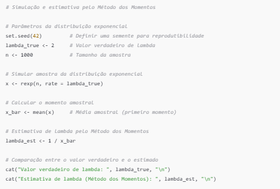

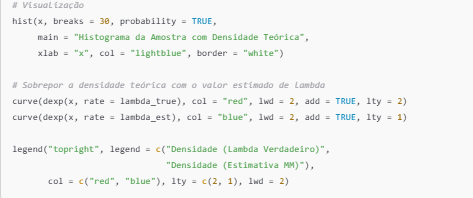

[figure not shown]

# 3 Estimação por Máxima Verossimilhança para a Distribuição Normal

Considere uma amostra $X = \{x_1, x_2, \ldots, x_n\}$ extraída de uma população que segue uma **distribuição normal** $N(\mu, \sigma^2)$. Nosso objetivo é estimar os parâmetros $\mu$ (média) e $\sigma^2$ (variância) usando o método da máxima verossimilhança.

## 3.1 1. Função de verossimilhança

A função de densidade da normal é dada por:
$$f(x | \mu, \sigma^2) = \frac{1}{\sqrt{2\pi\sigma^2}} e^{-\frac{(x - \mu)^2}{2\sigma^2}}$$

Para uma amostra independente $X = \{x_1, x_2, \ldots, x_n\}$, a função de verossimilhança é:
$$L(\mu, \sigma^2) = \prod_{i=1}^n \frac{1}{\sqrt{2\pi\sigma^2}} e^{-\frac{(x_i - \mu)^2}{2\sigma^2}}$$

## 3.2 2. Log-verossimilhança

Para facilitar os cálculos, trabalhamos com o logaritmo da função de verossimilhança:
$$\ell(\mu, \sigma^2) = \ln L(\mu, \sigma^2) = -\frac{n}{2} \ln(2\pi) - \frac{n}{2} \ln(\sigma^2) - \frac{1}{2\sigma^2} \sum_{i=1}^n (x_i - \mu)^2$$

## 3.3 3. Maximização

Para encontrar os estimadores de máxima verossimilhança (EMV), derivamos $\ell(\mu, \sigma^2)$ em relação a $\mu$ e $\sigma^2$, e igualamos a zero.

1. Derivada em relação a $\mu$:
   $$\frac{\partial \ell}{\partial \mu} = \frac{1}{\sigma^2} \sum_{i=1}^n (x_i - \mu)$$
   Igualando a zero:
   $$\hat{\mu} = \frac{1}{n} \sum_{i=1}^n x_i$$
   Ou seja, o EMV da média $\mu$ é a **média amostral** $\hat{\mu}$.
2. Derivada em relação a $\sigma^2$:
   $$\frac{\partial \ell}{\partial \sigma^2} = -\frac{n}{2\sigma^2} + \frac{1}{2(\sigma^2)^2} \sum_{i=1}^n (x_i - \mu)^2$$
   Igualando a zero:
   $$\hat{\sigma}^2 = \frac{1}{n} \sum_{i=1}^n (x_i - \hat{\mu})^2$$
   Ou seja, o EMV da variância $\sigma^2$ é a **variância amostral não corrigida**.

## 3.4 4. Estimadores Finais

- $\hat{\mu} = \frac{1}{n} \sum_{i=1}^n x_i$ (média amostral)
- $\hat{\sigma}^2 = \frac{1}{n} \sum_{i=1}^n (x_i - \hat{\mu})^2$ (variância amostral)

## 3.5 Simulação e resultado

### 3.5.1 Código gerador do gráfico

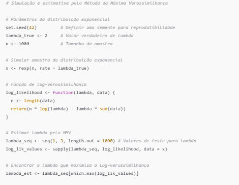

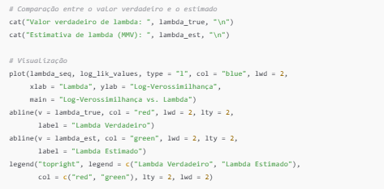

[figure not shown]

# 4 Função Linear Característica no Método dos Mínimos Quadrados

O **Método dos Mínimos Quadrados** é uma técnica amplamente utilizada para ajustar um modelo linear a um conjunto de dados. A ideia é minimizar a soma dos quadrados das diferenças entre os valores observados e os valores previstos pelo modelo.

## 4.1 1. Modelo Linear

A função linear característica é definida como:
$$y = \beta_0 + \beta_1 x$$
- $y$: Variável dependente (resposta). - $x$: Variável independente (preditor). - $\beta_0$: Intercepto da reta. - $\beta_1$: Inclinação da reta.

## 4.2 2. Função de Erro (Soma dos Quadrados dos Resíduos)

A função de erro é a soma dos quadrados das diferenças ($e_i$) entre os valores observados ($y_i$) e os valores ajustados ($\hat{y}_i$):
$$S(\beta_0, \beta_1) = \sum_{i=1}^n (y_i - (\beta_0 + \beta_1 x_i))^2$$
- $n$: Número de observações. - $y_i$: Valor observado. - $\hat{y}_i = \beta_0 + \beta_1 x_i$: Valor ajustado pelo modelo.

O objetivo do método é encontrar os valores de $\beta_0$ e $\beta_1$ que minimizem $S(\beta_0, \beta_1)$.

## 4.3 3. Derivação das Equações Normais

Minimizamos $S(\beta_0, \beta_1)$ derivando em relação a $\beta_0$ e $\beta_1$ e igualando as derivadas a zero:

### 4.3.1 3.1. Derivada em relação a $\beta_0$:

$$\frac{\partial S}{\partial \beta_0} = -2 \sum_{i=1}^n (y_i - \beta_0 - \beta_1 x_i) = 0$$

### 4.3.2 3.2. Derivada em relação a $\beta_1$:

$$\frac{\partial S}{\partial \beta_1} = -2 \sum_{i=1}^n x_i (y_i - \beta_0 - \beta_1 x_i) = 0$$

Resolvendo essas equações simultaneamente, obtemos as **equações normais**: 1.
$$\sum y_i = n \beta_0 + \beta_1 \sum x_i$$
2.
$$\sum x_i y_i = \beta_0 \sum x_i + \beta_1 \sum x_i^2$$

## 4.4 4. Solução para os Coeficientes

Resolvendo as equações normais, obtemos os estimadores de $\beta_0$ e $\beta_1$:

1. Inclinação ($\beta_1$):
   $$\beta_1 = \frac{n \sum x_i y_i - \sum x_i \sum y_i}{n \sum x_i^2 - (\sum x_i)^2}$$
2. Intercepto ($\beta_0$):
   $$\beta_0 = \bar{y} - \beta_1 \bar{x}$$
   - $\bar{x}$: Média dos valores de $x$.
   - $\bar{y}$: Média dos valores de $y$.